# cm008 Exercises: Fix the Plots

In this worksheet, we’ll be looking at some erroneous plots and fixing them.

I think you might not have these two packages installed:

```
install.packages("ggridges")
install.packages("scales")
```

```r
library(tidyverse)
library(gapminder)
library(ggridges)
library(scales)
```

## Exercise 1: Overlapping Points

After fixing the error, fix the overlapping problem in the following plot (attribution: [“R for data science”](https://r4ds.had.co.nz/data-visualisation.html)).

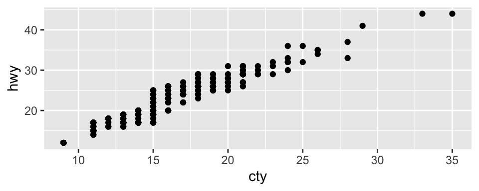

```r
# BEFORE
ggplot(mpg, aes(cty, hwy)) +
  geom_point()
```

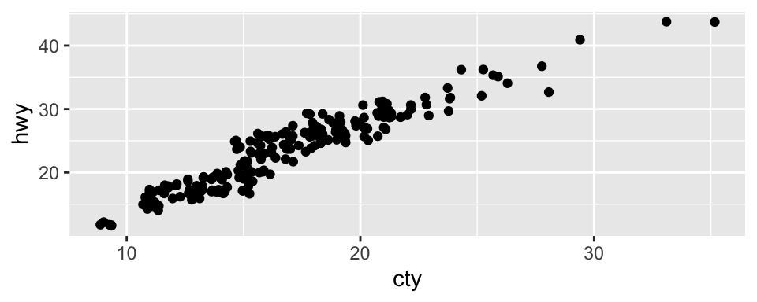

```r
# AFTER
# Use geom_jitter to spread the points out
ggplot(mpg, aes(cty, hwy)) +
  geom_jitter()
```

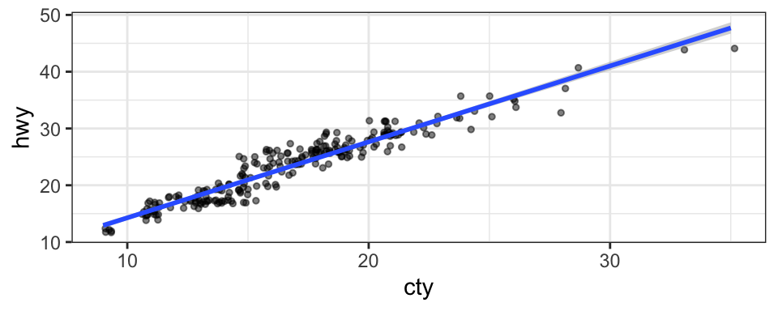

```r
# use geom_smooth, method = "lm" means linear regression model
ggplot(mpg,aes(cty,hwy)) +
    geom_jitter(alpha = 0.5, size =1) +
    geom_smooth(method = "lm") +
    theme_bw()
```

## Exercise 2: Line for each Country

Fix this plot so that it shows life expectancy over time *for each country*. Notice that `ggplot2` ignores the grouping of a tibble!

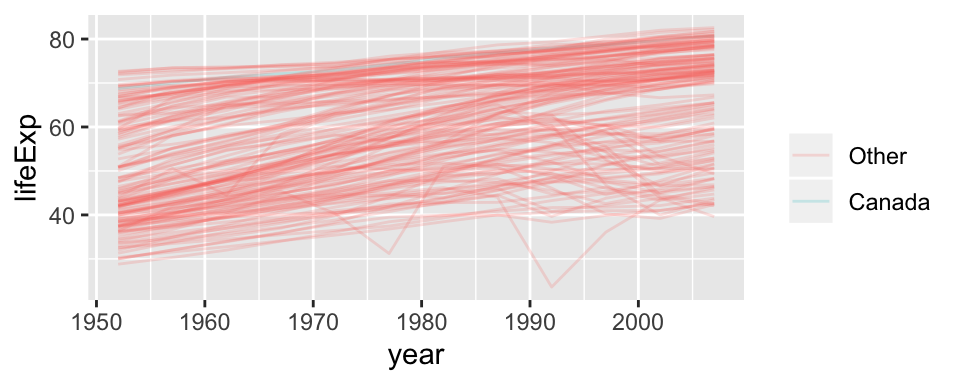

```r
# plots look the same besides group_by
# group_by mostly used for summarise
gapminder %>%
  group_by(country) %>%
  ggplot(aes(year, lifeExp, group = country, colour = country == "Canada")) +
  geom_line(alpha = 0.2) +
  scale_colour_discrete("", labels = c("Other", "Canada"))
```

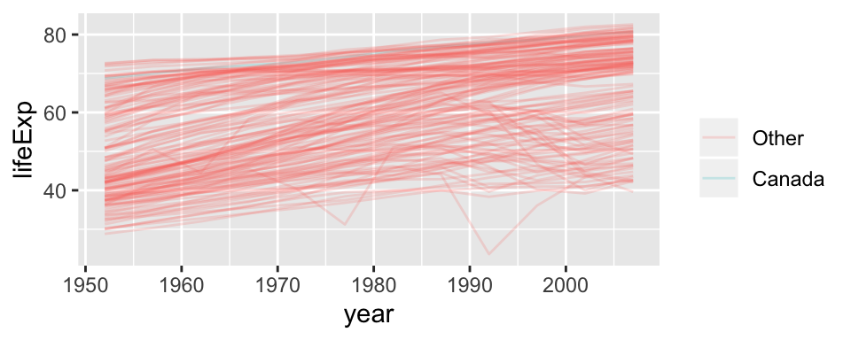

```r
gapminder %>%
#  group_by(country) %>%
  ggplot(aes(year, lifeExp, group = country, colour = country == "Canada")) +
  geom_line(alpha = 0.2) +
  scale_colour_discrete("", labels = c("Other", "Canada"))
```

## Exercise 3: More gdpPercap vs lifeExp

### 3(a) Facets

- Change the x-axis text to be in “comma format” with `scales::comma_format()`.
- Separate each continent into sub-panels.

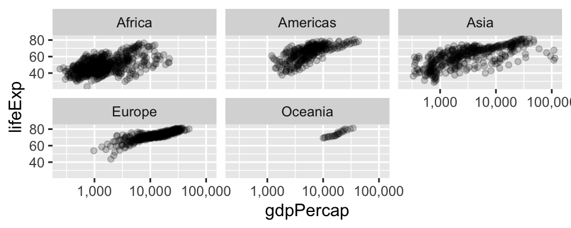

```r
# facet_wrap(~ continent, scales="free")
# can use scales = "free_y" etc
ggplot(gapminder, aes(gdpPercap, lifeExp)) +
  geom_point(alpha = 0.2) +
  scale_x_log10(labels = comma_format()) +
  facet_wrap(~ continent)
```

### 3(b) Bubble Plot

- Put the plots in one row, and free up the axes.
- Make a bubble plot by making the size of the points proportional to population.
  - Try adding a `scale_size_area()` layer too (could also try `scale_radius()`).
- Use `shape=21` to distinguish between `fill` (interior) and `colour` (exterior).

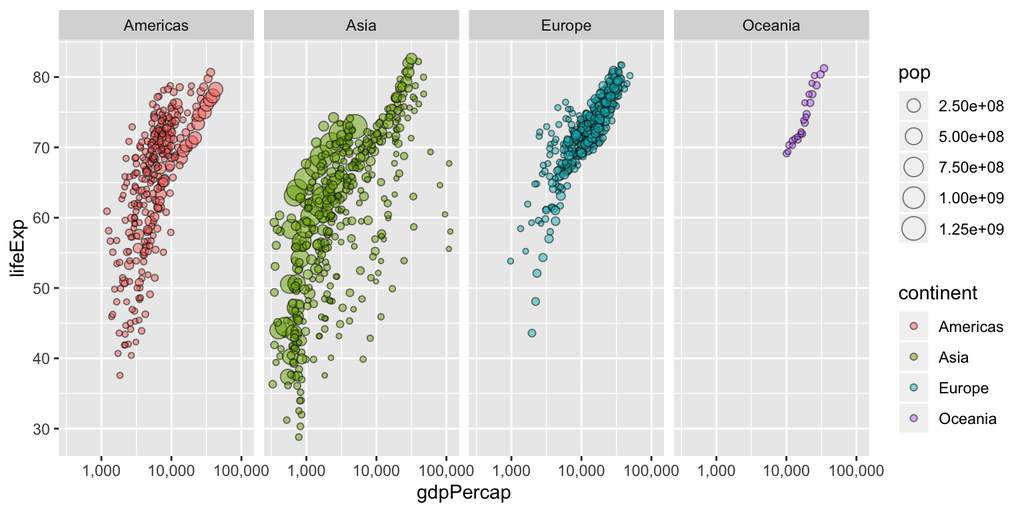

```r
  # colour identifies with perimeter/outside of the object
 # fill identifies with the fill of the shape
gapminder %>%
  filter(continent != "Africa") %>%
  ggplot(aes(gdpPercap, lifeExp, size = pop, fill = continent)) +
  facet_wrap(~ continent, nrow = 1) +
  geom_point(alpha = 0.5, shape = 21) +
  scale_x_log10(labels = scales::comma_format())
```

```r
  scale_size_area()
```

```
## <ScaleContinuous>
##  Range:
##  Limits:    0 --    1
```

A list of shapes can be found [at the bottom of the `scale_shape` documentation](https://ggplot2.tidyverse.org/reference/scale_shape.html).

### 3(c) Size “not working”

Instead of alpha transparency, suppose you’re wanting to fix the overplotting issue by plotting small points. Why is this not working? Fix it.

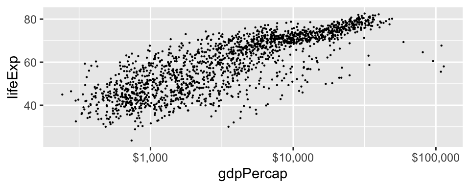

```r
# move size out of aes()
ggplot(gapminder) +
  geom_point(aes(gdpPercap, lifeExp), size = 0.1) +
  scale_x_log10(labels = scales::dollar_format())
```